# Taller SARIMAX - Series de tiempo , **Maestria en inteligencia de negocios**

Diego Hernando Miranda Jimenez

2026-03-07

### **Introducción del dataset**

Este archivo contiene datos sintéticos de ventas de tiendas minoristas mensuales de una tienda ficticia, que abarca el período de enero de 2020 a diciembre de 2023 (4 años).

La ubicación del dataset, se encuentra en: https://www.kaggle.com/code/muhammadzamin1/sales-forcasting/input

| Columna | Descripción |
| --- | --- |
| Date | Primer día de cada mes (formato: AAAA-MM-DD) |
| SalesAmount | Importe total de ventas mensuales (con estacionalidad y tendencia) |
| Promotion | Bandera binaria (1 = campaña promocional activa, 0 = sin promoción) |
| HolidayMonth | Bandera binaria (1 = mes festivo, p. ej., diciembre, 0 = mes normal) |

#### **Librerias necesarias para el taller**

```r
library(readr)
library(TSA)
library(forecast)
library(tseries)
library(ggplot2)
```

#### **Lectura de los datos**

```r
Datos <- read_csv2("Datos/retail_sales_mock_data.csv") #función para leer csv sep;
```

El Dataset contiene dos variables exogenas, “Promotion” y “HolidayMonth”, estas dos columnas pueden servirnos como exogenas para nuestro modelo. Para efectos de este ejercicio solo usaremos la exogena “Promotion”

#### **Serie de la variable objetivo y la exogena, exploración inicial**

```r
Total = ts(Datos[1:48,2], start =2020, frequency =12 )
Promotion = ts(Datos[1:48,3], start =2020, frequency =12 )
```

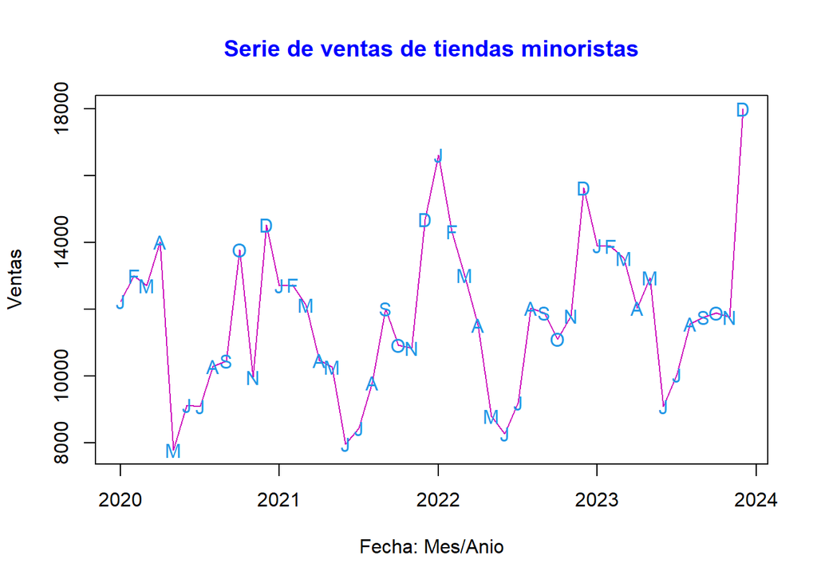

```r
plot(Total,col="6", ann=FALSE)
points(y=Total,x=time(Total),pch=as.vector(season(Total)),col="4")
title(main="Serie de ventas de tiendas minoristas", col.main="blue", font.main=2)
title(xlab="Fecha: Mes/Anio")
title(ylab="Ventas")
```

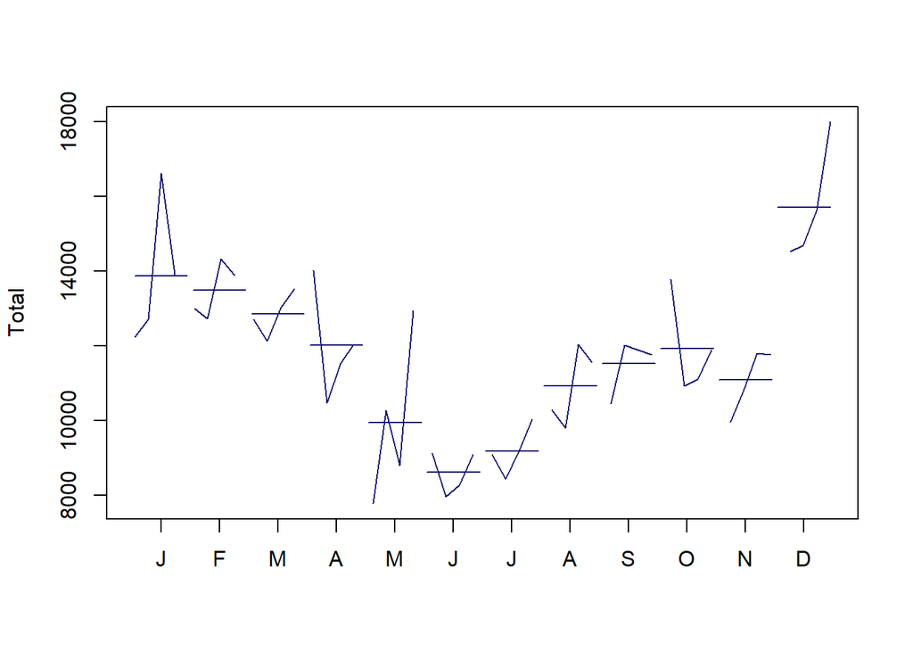

```r
monthplot(Total, col = "midnightblue")
```

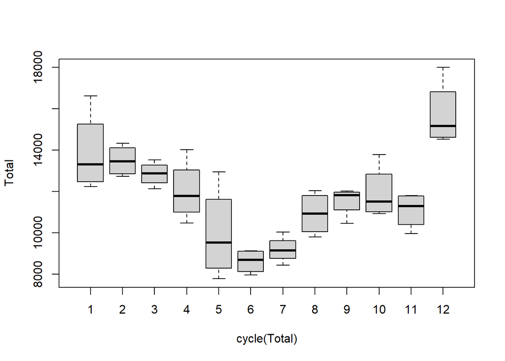

```r
boxplot(Total~cycle(Total))
```

En el gráfico de líneas de la serie original se observa un patrón estacional claramente definido entre los mismos meses de diferentes años. Por ejemplo, los meses identificados con la letra “D” presentan picos altos, mientras que en mayo, junio y julio se evidencian caídas. Esto permite concluir que la serie no sigue un comportamiento aleatorio, sino que responde a patrones estacionales marcados.

Además, se aprecia una ligera tendencia creciente. Aunque los picos mensuales se repiten de manera cíclica cada año, estos parecen ser gradualmente más altos con el paso del tiempo. Este comportamiento sugiere una tendencia positiva en la serie, lo que podría indicar que no es estacionaria en media. En ese caso, podría ser necesario aplicar una diferenciación regular para estabilizarla. En cuanto a la estacionariedad en varianza, visualmente la serie tampoco parece cumplir esta condición, ya que los picos y valles —que se repiten anualmente— no muestran una variabilidad constante. Más bien, dicha variabilidad tiende a aumentar con el tiempo.

Esta interpretación se refuerza con el boxplot, donde se observa con claridad la estacionalidad de la serie: los valores aumentan desde agosto hasta enero y descienden desde febrero hasta alcanzar sus niveles más bajos en junio y julio. Asimismo, se nota una alta variabilidad entre los meses. Resulta particularmente llamativo el comportamiento de mayo (mes 5), cuya caja es más amplia respecto a la de junio, lo cual podría indicar que en algunos años las ventas de ese mes fueron muy buenas y en otros muy bajas. Finalmente, en diciembre (mes 12) se aprecia el posible efecto “Navidad”, cuya intensidad varía de un año a otro.

Todo lo anterior, en el contexto del mercado minorista, resulta completamente coherente. Si consideramos, por ejemplo, que los datos provienen de una tienda que comercializa productos navideños o de alta demanda en determinadas épocas del año, es lógico que las ventas comiencen a aumentar después de julio y alcancen su punto máximo hacia diciembre. Posteriormente, al llegar enero, se observa una rápida caída. Este comportamiento refleja dinámicas comerciales reales y permite identificar patrones estacionales claros dentro de los datos.

### **Introducción al modelamiento, ajustes al modelo Box - Jenkins**

```r
ndiffs(Total) #Detecta automaticamente cuantas diferencias ordinarias pueden se necesarias
```

```
## [1] 0
```

```r
nsdiffs(Total) #Detecta automaticamente cuantas diferencias estacionales pueden se necesarias
```

```
## [1] 1
```

Al aplicar las pruebas de diferenciación regular y diferenciación estacional, se obtiene un valor de 0 para la diferenciación regular, lo cual sugiere que, matemáticamente, la serie es estacionaria en media. Esto indica que, aunque visualmente se apreciaba una ligera tendencia creciente en el gráfico de líneas, no existe un crecimiento o decrecimiento lo suficientemente significativo como para requerir alguna transformación adicional. Por otro lado, la diferenciación estacional presenta un valor de 1, lo que confirma el patrón observado visualmente: existe una relación estacional entre los mismos meses de distintos años. En consecuencia, es apropiado aplicar una diferenciación estacional de orden 1, o más si fuera necesario, para capturar adecuadamente dicha estacionalidad.

#### **Realizar prueba de Dickey-Fuller aumentada (ADF)**

- Hipótesis nula (H<sub>0</sub>): La serie **no es estacionaria**
- Hipótesis alternativa (H<sub>1</sub>): La serie es **estacionaria**

```r
adf<-adf.test(Total)
adf$p.value
```

```
## [1] 0.02058675
```

Al obtener un **p-value**, menor que 0.05, rechazamos la hipótesis nula y aceptamos la alternativa, donde se considera que la serie de ventas de tienda minorista retail es **estacionaria** y concluimos que no se necesitaran diferencias ordinarias sobre la serie, por que está no tiene tendencia

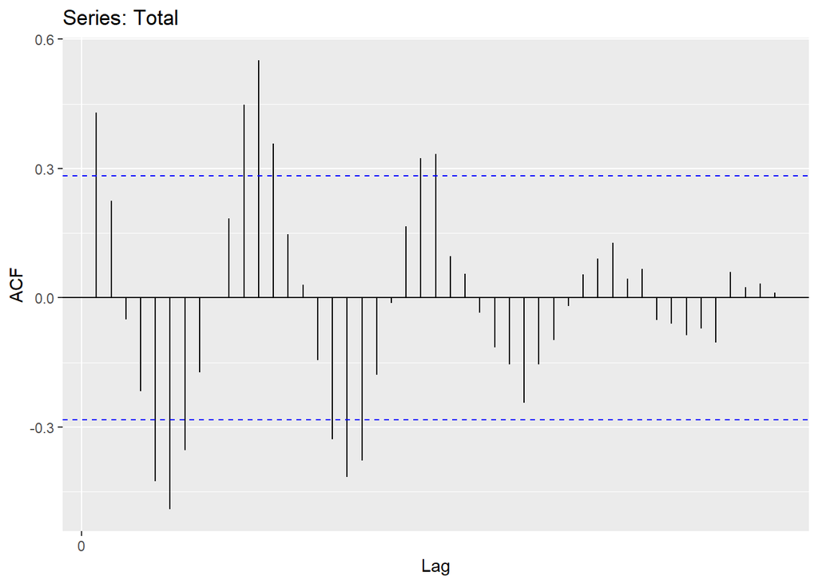

```r
autoplot(acf(Total, plot = FALSE,lag=48))
```

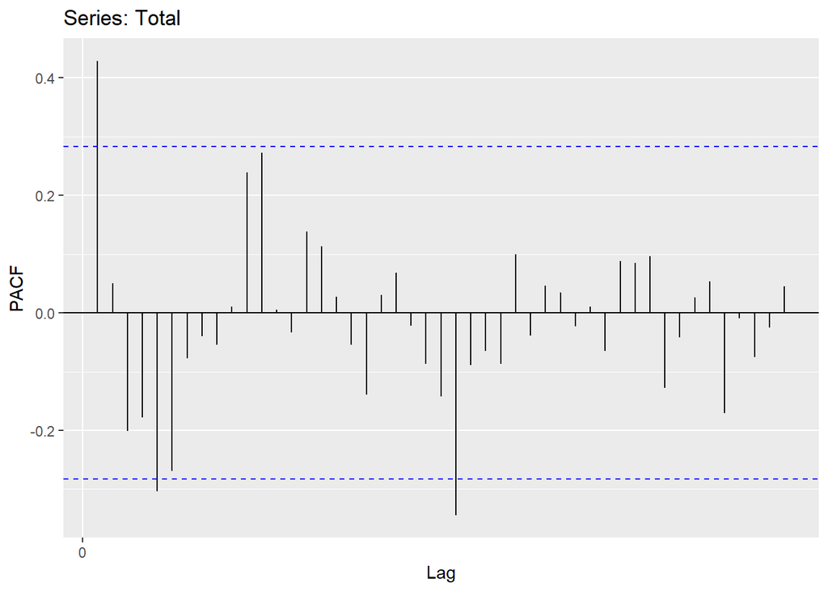

```r
autoplot(pacf(Total, plot = FALSE, lag = 48))
```

En la función de autocorrelación parcial (PACF), se observa que la barra correspondiente al rezago 1 sobresale significativamente de las bandas de confianza. Esto sugiere la presencia de un término autorregresivo de orden 1 (AR(1)), lo que indicaría que el valor del mes actual depende directamente del valor del mes inmediatamente anterior. Estos supuestos se considerarán en la etapa de proposición de modelos. Asimismo, podría plantearse la incorporación de un valor $P$ para la componente estacional, dado que el rezago 12 se encuentra cercano al límite de la banda de confianza. Este aspecto también será evaluado en la mencionada etapa de modelamiento donde podriamos probar con un model de orden $P$ = 1 o $P$ = 0

#### **Diferenciando la serie una vez de manera estacional”**

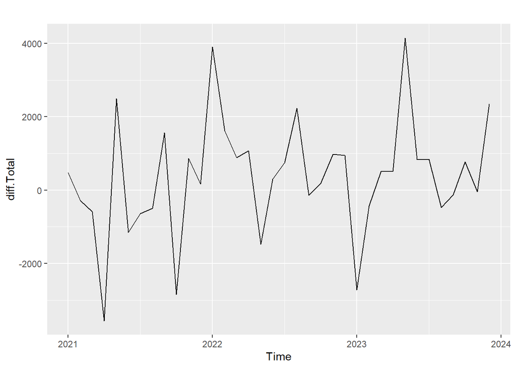

```r
diff.Total<-diff(Total, lag = 12)
autoplot(diff.Total, ts.colour = "darkorange4", ts.linetype = "dashed")
```

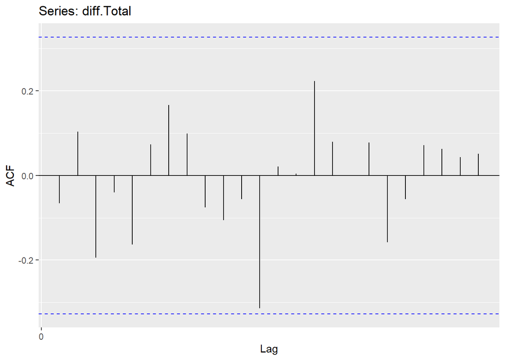

```r
autoplot(acf(diff.Total, plot = FALSE,lag=24))
```

Con base en lo anterior, se concluye que al aplicar una diferencia estacional a la serie de ventas de tiendas minoristas del canal retail, es posible capturar el patrón observado en los rezagos 12, 24 y 36, eliminando en gran medida la componente anual. Aunque el “limpiamiento” del patrón no fue completo, las barras de la función de autocorrelación se encuentran dentro de las bandas de confianza, lo que indica que la estacionalidad fue adecuadamente atenuada.

### **Propuesta de modelos**

En el siguiente apartado se propondrán tres modelos SARIMA, basados en la experiencia y en la información obtenida del análisis de la serie en los pasos anteriores. El objetivo es identificar, al menos, dos modelos que superen satisfactoriamente la verificación de los residuos y, entre estos, seleccionar el modelo ganador considerando la menor varianza residual, los menores criterios de información o el menor error cuadrático medio (ECM) en sus pronósticos. Posteriormente, se estimarán los parámetros de cada modelo y, sobre el modelo ganador, se incorporará la **variable exógena Promotion**, convirtiéndolo así en un modelo **SARIMAX.**

```r
fit1 <- Arima(Total, order = c(1, 0, 1), seasonal = c(0, 1, 1))
fit2 <- Arima(Total, order = c(1, 0, 0), seasonal = c(1, 1, 0))
fit3 <- Arima(Total, order = c(0, 0, 1), seasonal = c(0, 1, 1))
```

```r
# Comparación de Criterios de Información (Menor es mejor)
comparativa_criterios <- data.frame(
  Modelo = c("M1: (1,0,1)(0,1,1)", "M2: (1,0,0)(1,1,0)", "M3: (0,0,1)(0,1,1)"),
  AIC = c(fit1$aic, fit2$aic, fit3$aic),
  BIC = c(fit1$bic, fit2$bic, fit3$bic)
)
print(comparativa_criterios)
```

```
##               Modelo      AIC      BIC
## 1 M1: (1,0,1)(0,1,1) 636.7973 643.1314
## 2 M2: (1,0,0)(1,1,0) 637.1833 641.9338
## 3 M3: (0,0,1)(0,1,1) 637.4500 642.2006
```

```r
# Unir las precisiones en una sola tabla
precis_m1 <- accuracy(fit1)
precis_m2 <- accuracy(fit2)
precis_m3 <- accuracy(fit3)

tabla_accuracy <- rbind(precis_m1, precis_m2, precis_m3)
rownames(tabla_accuracy) <- c("Modelo 1", "Modelo 2", "Modelo 3")
print(tabla_accuracy)
```

```
##                ME     RMSE      MAE      MPE     MAPE      MASE        ACF1
## Modelo 1 201.4634 1192.882 723.3963 1.037047 6.003946 0.6001906 -0.11395248
## Modelo 2 330.2364 1308.773 843.3089 2.133128 7.031258 0.6996801 -0.06792498
## Modelo 3 330.6898 1314.581 821.9875 2.121566 6.841111 0.6819901 -0.04859417
```

Para la validación y selección del modelo, primero realizamos una comparación de AIC/BIC, en este punto vemos que el modelo 1, tiene el **AIC** más bajo 636.79, esto podría indicar que este modelo es el que mejor balancea el ajuste con la complejidad.

EL modelo 2 tiene el **BIC** más bajo, esto podría ser engañoso si no revisamos otras metricas del modelo como por ejemplo su RMSE o su MAPE.

Respeto al análisis de preción vemos que el modelo 1 toma distancia totalmente de los otros dos modelos:

- **RMSE (Error Cuadrático Medio):** El Modelo 1 tiene 1192.8, significativamente menor al ~1300 de los otros.
- **MAPE (Error Porcentual Medio):** El Modelo 1 tiene un error del 6.00%, mientras que los demás superan el 6.8% - 7%.

#### **Validación de residuales**

Ahora ya que tenemos claro cual es nuestro modelo lider **(Modelo 1)**, haremos pruebas en los residuales para verificar que cumplan con las premisas de los residuales en series de tiempo. Los dos modelos **SARIMA** propuestos para ser testeados en los residuales y del cual saldrá el modelo ganador para el pronostico serán el **modelo 1** (modelo ganador por criterios de información y accuracy) y el **modelo 3** el cual tuvo también un comportamiento interesante, esto en pro de hacer el testeo propuesto en el taller sobre dos modelos **SARIMA** y que sus residuales pasen las pruebas.

##### **Modelo 1:**

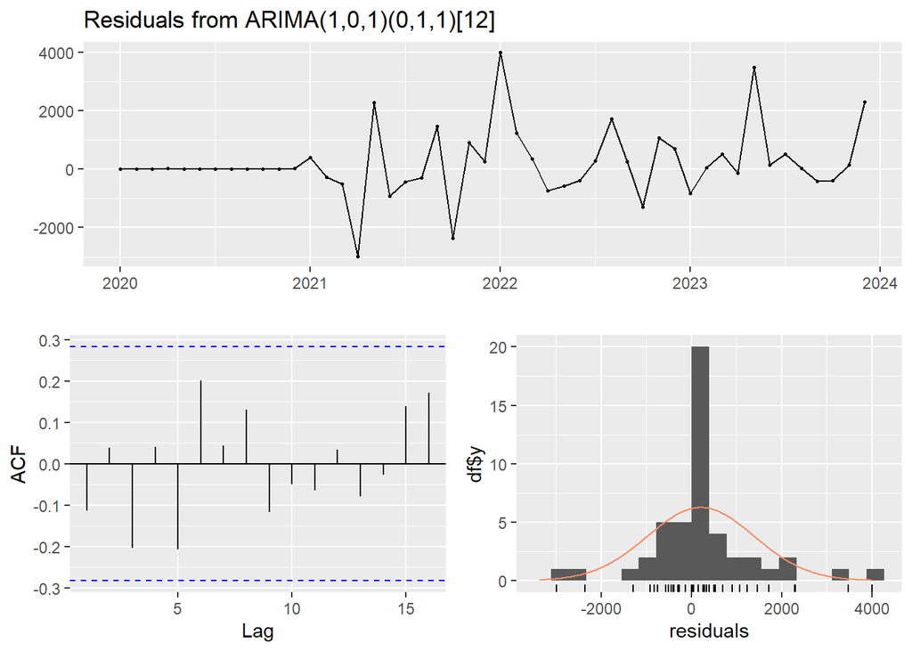

```
##
##  Ljung-Box test
##
## data:  Residuals from ARIMA(1,0,1)(0,1,1)[12]
## Q* = 9.8951, df = 7, p-value = 0.1946
##
## Model df: 3.   Total lags used: 10
```

```r
# Diagnóstico completo para el Modelo 1
checkresiduals(fit1)
```

Se aplicó el test de **Ljung-Box** sobre los residuales del **Modelo 1** para verificar el supuesto de independencia. Se obtuvo un estadístico $Q^* = 9.8951$ con un p-valor de 0.1946. Dado que este valor es superior al nivel de significancia $\alpha = 0.05$, no existe evidencia estadística suficiente para rechazar la hipótesis nula de independencia. Por lo tanto, se confirma que los residuales se comportan como ruido blanco, validando la estructura del modelo para fines de predicción

También en las graficas vemos que los residuales en su grafica de ACF, están todos dentro de las bandas de confianza, además en el histograma se observa que los errores están situados en su mayoria sobre cero, cumpliendo también este supuesto.

La varianza parece ser constante y no muestra variabilidad constante, el modelo parece también cumplir con este supuesto.

##### **Modelo 3**

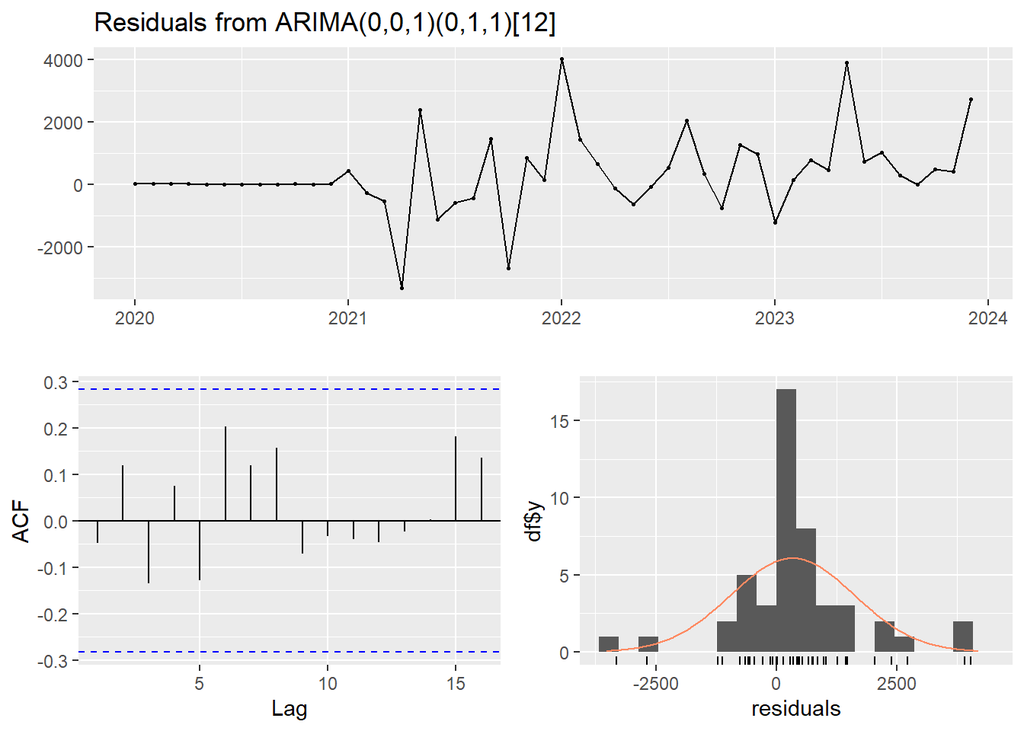

```
##
##  Ljung-Box test
##
## data:  Residuals from ARIMA(0,0,1)(0,1,1)[12]
## Q* = 8.106, df = 8, p-value = 0.4232
##
## Model df: 2.   Total lags used: 10
```

```r
# Diagnóstico completo para el Modelo 3
checkresiduals(fit3)
```

Se realizó el diagnóstico de los residuales para el **Modelo 3**. El test de **Ljung-Box** arrojó un estadístico $Q^* = 8.106$ con un p-valor de 0.4232. Al ser este valor significativamente superior al umbral de $0.05$, se concluye que no existe autocorrelación serial en los errores y no existe evidencia estadistica suficiente para rechazar la hipótesis nula, por ende la aceptamos. Cabe destacar que este modelo presenta el mayor p-valor entre los candidatos, lo que indica una excelente captura de la estructura de autocorrelación de la serie, convirtiéndolo en un segundo candidato muy confiable.

También en las graficas vemos que los residuales en su grafica de ACF, están todos dentro de las bandas de confianza, además en el histograma se observa que los errores están situados en su mayoria sobre cero, cumpliendo también este supuesto.

La varianza parece ser constante y no muestra variabilidad constante, el modelo parece también cumplir con este supuesto.

### **El modelo ganador**

Luego de evaluar múltiples modelos, realizar pruebas, validaciones estadísticas y un análisis detallado de su estructura de correlación, estacionalidad y estacionariedad, se seleccionó el **Modelo 1** como el mejor candidato para generar los pronósticos. Esta elección se fundamenta en que presenta los valores más bajos en los criterios AIC, RMSE y MAPE, superando así el desempeño de los otros dos modelos, además de cumplir con los supuestos en los residuales.

En consecuencia, el Modelo 1 será el candidato principal para la etapa de pronóstico, sobre el cual se incorporará la variable exógena Promotion, convirtiéndolo en un modelo SARIMAX.

#### *Escritura matematica del modelo 1*

$$\begin{equation}
(1 - \phi_1 B) (1 - B^{12})Y_t = \beta Promotion + (1 + \theta_1 B)(1 +
\Theta_1 B^{12}) \epsilon_t
\end{equation}$$

**Definición de Convenciones y Operadores:**

$Y_t$: Representa la serie de ventas minoristas en el tiempo $t$.

$X_t$: Es la variable exógena Promotion en el tiempo $t$.

$B$: Es el operador de rezago, definido como $B^k Y_t = Y_{t-k}$.

$(1 - B^{12})$: Es el operador de diferencia estacional ($D=1$), aplicado para estabilizar la serie eliminando la estacionalidad anual.

$\phi_1$: Es el parámetro autorregresivo de orden 1 (AR1).

$\theta_1$: Es el parámetro de media móvil de la parte regular (MA1).

$\Theta_1$: Es el parámetro de media móvil de la parte estacional (SMA1).

$\beta$: Es el coeficiente de regresión que mide el impacto de las promociones sobre las ventas.

$\epsilon_t$: Es el término de error aleatorio o ruido blanco, donde $\epsilon_t \sim N(0, \sigma^2)$.

### **Pronosticos y validación cruzada**

Durante la etapa anterior, definimos y seleccionamos el modelo 1 como candidato y modelo ganador para ser utilizado en la fase de predicciones y validaciones. Partimos de este modelo debido a su bajo MAPE y RMSE en comparación con los demás modelos, además de presentar valores de criterios de información muy similares a los restantes.

En esta nueva etapa de experimentación, con el objetivo de comparar el desempeño predictivo, el MAPE, el RMSE y otras métricas de rendimiento (incluyendo ahora la variable regresora exógena), emplearemos de manera experimental los modelos 1 y 3, previamente explorados y validados.

A continuación, se tomarán los modelos 1 y 3 para realizar pronósticos y validación cruzada con los datos intramuestrales, dividiendo el conjunto de datos en proporciones de entrenamiento y prueba.

Para este ejercicio, se decidió entrenar los modelos dividiendo la muestra de la siguiente manera:

- 3 años (36 meses) para el entrenamiento.
- 1 año (12 meses) para la prueba.

Esto se definió considerando que el conjunto de datos cuenta con un total de 48 meses de información. En consecuencia, se crearán los conjuntos de entrenamiento y prueba tanto para la variable objetivo (Ventas) como para la variable exógena (Promoción).

```r
# Preparación de Datos: División Train/Test
# Variable Objetivo (Ventas)
train_y <- window(Total, end = c(2022, 12))
test_y  <- window(Total, start = c(2023, 1))

# Variable Exógena (Promotion)
train_x <- window(Promotion, end = c(2022, 12))
test_x  <- window(Promotion, start = c(2023, 1))
```

Posterior a tener los datos divididos en test y prueba, procedemos a a crear nuestro modelos SARIMAX, usando la regresora exogena $Promotion$ para el *modelo 1* y *modelo 3*, previamente revisados en este taller y revisados según los supuestos establecidos.

```r
#Ajuste de Modelos SARIMAX (Usando xreg Promotion)

# Modelo 1: SARIMAX(1,0,1)(0,1,1)[12]
fit1_x <- Arima(train_y, order = c(1, 0, 1),
                seasonal = list(order = c(0, 1, 1), period = 12),
                xreg = train_x,
                method = "ML")

# Modelo 3: SARIMAX(0,0,1)(0,1,1)[12]
fit3_x <- Arima(train_y, order = c(0, 0, 1),
                seasonal = list(order = c(0, 1, 1), period = 12),
                xreg = train_x,
                method = "ML")
```

En el fragmento de código anterior durante el ajuste de los modelos SARIMAX sobre el conjunto de entrenamiento, se presentó un error de no-estacionariedad en la parte AR. Esto ocurrió porque el método de estimación por defecto (CSS) no lograba converger a una solución estable debido al tamaño reducido de la muestra de entrenamiento (36 datos) y la inclusión de la variable exógena. El problema se resolvió cambiando el método de estimación a Máxima Verosimilitud (ML), el cual es más robusto y asegura que los parámetros estimados mantengan la estabilidad del sistema.

El error que aparecia inicialmente, antes de agregar el paramentro $method="ML"$, era:

Error en stats::arima(x = x, order = order, seasonal = seasonal, xreg = xreg, : non-stationary AR part from CSS

Se resolvió efectivamente cambiando el método de estimaciómn por defecto que usa R *CSS* (Conditional Sum of Squares) a *ML* (Exact Maximun likelihood)

Ahora, procederemos a generar los pronósticos fuera de la muestra utilizando los datos de prueba requiere que el modelo conozca la información de la variable exógena. Es fundamental que el modelo sepa si existen promociones en los datos de testeo para poder realizar correctamente las predicciones y la validación de los modelos.

```r
fc1_x <- forecast(fit1_x, xreg = test_x)
fc3_x <- forecast(fit3_x, xreg = test_x)
```

```r
#Tabla Comparativa de Métricas (ECM/RMSE y MAPE)
res_m1 <- accuracy(fc1_x, test_y)
res_m3 <- accuracy(fc3_x, test_y)

tabla_final <- rbind(
  res_m1[1, c("RMSE", "MAPE")], # M1 Train
  res_m1[2, c("RMSE", "MAPE")], # M1 Test
  res_m3[1, c("RMSE", "MAPE")], # M3 Train
  res_m3[2, c("RMSE", "MAPE")]  # M3 Test
)
rownames(tabla_final) <- c("SARIMAX 1 (Train)", "SARIMAX 1 (Test)",
                           "SARIMAX 3 (Train)", "SARIMAX 3 (Test)")
print("Resumen de Métricas de Pronóstico:")
```

```
## [1] "Resumen de Métricas de Pronóstico:"
```

```r
print(tabla_final)
```

```
##                        RMSE     MAPE
## SARIMAX 1 (Train)  487.1846 2.951097
## SARIMAX 1 (Test)   732.7832 3.465446
## SARIMAX 3 (Train)  722.5048 4.466961
## SARIMAX 3 (Test)  1092.1944 6.139845
```

**Análisis de Validación Cruzada y Poder Predictivo:**

Para este análisis, se reservaron 12 meses (un año completo) como muestra de prueba (test), lo que representa el 25% de los datos totales. Esta elección es estratégica, ya que permite evaluar si el modelo es capaz de capturar un ciclo estacional completo (enero a diciembre) sin conocer los valores reales.

1. Superioridad del Modelo 1: El SARIMAX 1 es claramente el ganador en términos de poder predictivo. Su error porcentual en la muestra de testeo (3.46%) es significativamente menor al del Modelo 3 (6.13%).
2. Estabilidad del Error: Observamos que en el Modelo 1, la diferencia entre el MAPE de entrenamiento (2.95%) y el de testeo (3.46%) es pequeña. Esto indica que el modelo no tiene sobreajuste (overfitting) y generaliza muy bien ante datos nuevos.
3. Precisión del Modelo 3: Aunque el Modelo 3 pasó las pruebas de residuales, su capacidad de pronóstico es inferior, con un RMSE de 1092.19 frente a los 732.78 del Modelo 1.

**Justificación Final del Modelo Adecuado**

El modelo seleccionado como definitivo es el SARIMAX $(1,0,1)(0,1,1)_{12}$ con la variable exógena $Promotion$. Las razones que lo validan son:

- Poder Predictivo: Presentó el menor error fuera de la muestra (MAPE de 3.46%), lo que garantiza pronósticos más confiables para la toma de decisiones de negocio.
- Estructura Completa: A diferencia del Modelo 3, el Modelo 1 incluye un componente AR(1). Los resultados demuestran que el valor del mes anterior es un predictor crítico para las ventas de esta tienda.
- Impacto de la Exógena: Al incluir Promotion, el modelo logra explicar variaciones que el componente estacional por sí solo no capturaba, reduciendo el error global.

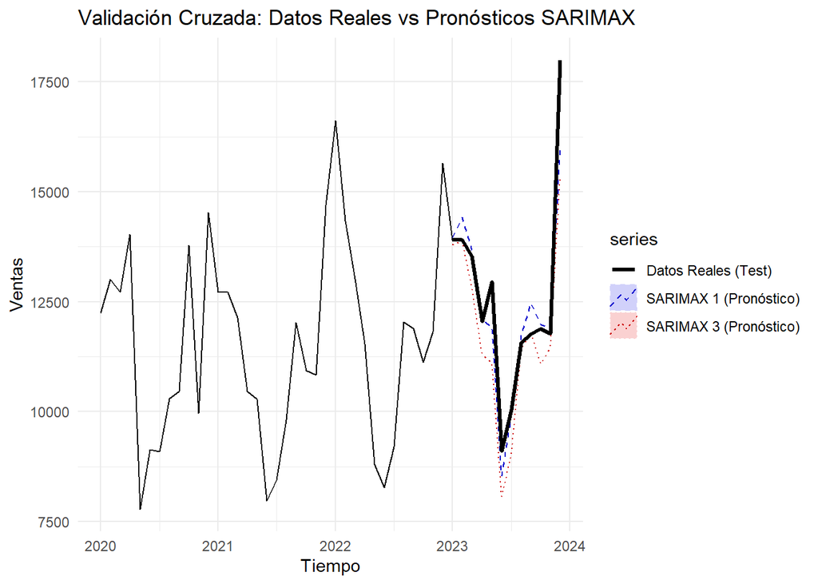

```r
# Visualización de la Validación
autoplot(Total, main = "Validación Cruzada: Datos Reales vs Pronósticos SARIMAX",
         ylab = "Ventas", xlab = "Tiempo") +
  autolayer(fc1_x, series = "SARIMAX 1 (Pronóstico)", PI = FALSE, linetype = "dashed") +
  autolayer(fc3_x, series = "SARIMAX 3 (Pronóstico)", PI = FALSE, linetype = "dotted") +
  autolayer(test_y, series = "Datos Reales (Test)", lwd = 1.1) +
  theme_minimal() +
  scale_color_manual(values = c("black", "blue", "red"))
```

El gráfico muestra claramente cómo el SARIMAX 1 (línea azul punteada) tiene una capacidad superior para seguir la trayectoria de los Datos Reales (línea negra) en el periodo de 2023, especialmente capturando la magnitud de los picos y las caídas estacionales mejor que el Modelo 3.

Para el caso de la variable exogena $Promotion$, valdría la pena entender su coeficiente y su interpretación e impacto en la serie, tanto desde el punto de vista mátematico como de la inteligencia de negocios, para eso ejecutamos el siguiente comando:

```r
summary(fit1_x)
```

```
## Series: train_y
## Regression with ARIMA(1,0,1)(0,1,1)[12] errors
##
## Coefficients:
##          ar1      ma1     sma1  Promotion
##       0.9998  -0.8191  -0.9214  2889.7636
## s.e.  0.0030   0.1307   0.6268   297.7898
##
## sigma^2 = 427228:  log likelihood = -193.4
## AIC=396.79   AICc=400.13   BIC=402.68
##
## Training set error measures:
##                    ME     RMSE      MAE      MPE     MAPE      MASE       ACF1
## Training set 116.0827 487.1846 320.1556 1.013236 2.951097 0.2594191 -0.2227138
```

El análisis del modelo SARIMAX revela que la variable exógena Promotion tiene un impacto positivo y estadísticamente significativo sobre las ventas minoristas. El coeficiente estimado de 2,889.76 indica que las campañas promocionales desplazan el nivel base de ventas hacia arriba en esa magnitud. Dado que el estadístico de prueba ($Z \approx 9.7$) es considerablemente alto, se concluye que la estrategia de promociones es un motor clave del rendimiento comercial, aportando una mejora sustancial en la precisión del pronóstico al capturar variaciones que no dependen únicamente del ciclo estacional anual.”

$$Z = \frac{2889.76}{297.78} =
9.704$$
Para finalizar, y aprovechando la totalidad de los datos disponibles (4 años), se generará un pronóstico para un ciclo estacional completo de 12 meses, proyectando los valores correspondientes al año 2024. De esta manera, se obtendrán estimaciones para los próximos 12 meses.

Además, será necesario definir una estrategia de $Promoción$ para el año a pronosticar, ya que el modelo requiere conocer en qué meses se implementarán las campañas promocionales planificadas para el próximo año.

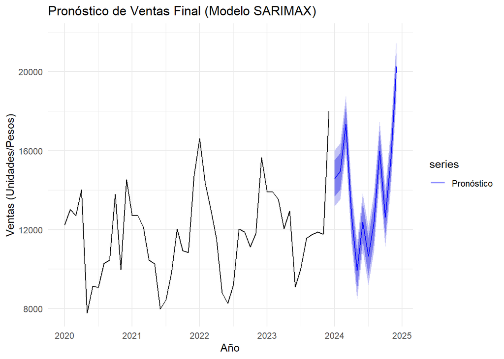

```r
#Pronóstico Final para el próximo año (12 meses adelante)

# Ajuste del modelo final con TODOS los datos históricos
fit_final <- Arima(Total, order = c(1, 0, 1),
                   seasonal = list(order = c(0, 1, 1), period = 12),
                   xreg = Promotion,
                   method = "ML")

# Definición del calendario de promociones futuro (Escenario de negocio)
# Supongamos que el equipo de marketing planea promociones en:
# Marzo (3), Junio (6), Septiembre (9), Noviembre (11) y Diciembre (12)
promo_futura <- c(0, 0, 1, 0, 0, 1, 0, 0, 1, 0, 1, 1)

# Convertir a serie de tiempo para el pronóstico
promo_futura_ts <- ts(promo_futura, start = c(2024, 1), frequency = 12)

# 3. Generación del pronóstico
pronostico_futuro <- forecast(fit_final, h = 12, xreg = promo_futura_ts)

# 4. Visualización del pronóstico final
library(ggplot2)
autoplot(pronostico_futuro,
         main = "Pronóstico de Ventas Final (Modelo SARIMAX)",
         ylab = "Ventas (Unidades/Pesos)",
         xlab = "Año") +
  theme_minimal() +
  autolayer(pronostico_futuro$mean, series = "Pronóstico", PI = FALSE) +
  scale_color_manual(values = c("blue"))
```

**Captura de la dinámica comercial:** Se nota claramente cómo el modelo proyecta ventas respetando la estacionalidad (las caídas a mitad de año) y dispara las ventas al final del periodo proyectado, capturando el “efecto diciembre”.

**Impacto de las Promociones:** Los picos adicionales que se ven a lo largo del 2024 corresponden directamente a esos “1” que pusiste en tu vector promo_futura. El modelo sumó exitosamente esos $\approx 2889$ de tu coeficiente $\beta$ a la base estacional.

**Incertidumbre (Intervalos de confianza):** Las sombras azules (al 80% y 95% de confianza) se van abriendo ligeramente a medida que avanza el año. Esto es un comportamiento matemáticamente correcto e ideal para un informe de Inteligencia de Negocios, ya que refleja que el futuro lejano tiene mayor incertidumbre que el futuro inmediato.

### **Conclusiones y cierre**

El desarrollo de este taller permitió proyectar exitosamente las ventas minoristas para el año 2024. Al transicionar de un análisis clásico de Box-Jenkins a un modelo SARIMAX, se logró no solo capturar la inercia histórica y la fuerte estacionalidad del sector retail (donde los picos de diciembre son evidentes), sino también cuantificar el impacto directo de las decisiones de negocio.

El resultado más destacado a nivel comercial es la validación estadística de la variable exógena $Promotion$. El modelo determinó que la ejecución de campañas promocionales incrementa las ventas mensuales en un promedio de 2889.76 unidades/pesos, un hallazgo altamente significativo ($Z \approx 9.70$) que demuestra un retorno real sobre la inversión en marketing. Finalmente, el pronóstico proyectado respeta los ciclos estacionales y ajusta dinámicamente las estimaciones en los meses donde se planean futuras promociones.

**Problemas Enfrentados y Soluciones implementadas**

Durante el proceso de modelamiento y validación, surgieron diversos retos técnicos que requerían ajustes metodológicos:

-**Inestabilidad Numérica en el Ajuste (Error de Estacionariedad AR):** Al realizar la validación cruzada y reducir la ventana de datos para el entrenamiento, la función Arima arrojó el error non-stationary AR part from CSS. Esto ocurrió porque el método de estimación por defecto (Conditional Sum of Squares) no lograba converger a una solución estable con una muestra pequeña. Solución: Se forzó al algoritmo a utilizar Máxima Verosimilitud Exacta (method = “ML”), un método más robusto que aseguró la estacionariedad y la correcta estimación de los parámetros.

-**Complejidad Estacional y Varianza Creciente:** El análisis exploratorio inicial mostró que la serie no era estacionaria en varianza y tenía un fuerte componente cíclico. Solución: Se aplicó una diferencia estacional ($D=1$) con rezago 12 (lag = 12). Esto limpió la autocorrelación anual y permitió estabilizar el patrón sin necesidad de sobre-diferenciar la serie ordinariamente.

-**Manejo del Ecosistema Gráfico en R:** Al generar las visualizaciones de pronóstico final, el sistema no reconocía las capas estéticas (theme_minimal()). Solución: Se identificó la dependencia de la librería ggplot2 dentro del ecosistema de forecast, y su importación explícita permitió generar gráficos limpios y con calidad de presentación ejecutiva.

**Justificación de la Elección del Modelo 1**

Tras evaluar tres estructuras candidatas, el Modelo 1 ($SARIMA(1,0,1)(0,1,1)_{12}$) fue seleccionado de manera concluyente como el mejor modelo predictivo, justificándose en los siguientes pilares:

-**Principio de Parsimonia y Ajuste:** El Modelo 1 presentó el Criterio de Información de Akaike (AIC) más bajo (636.79) en comparación con los demás modelos, indicando que logra el mejor equilibrio entre la bondad de ajuste y la simplicidad matemática.

-**Precisión y Poder Predictivo:** Durante la evaluación de las métricas de error en la muestra de entrenamiento, el Modelo 1 superó ampliamente a sus competidores, logrando el menor Error Cuadrático Medio (RMSE = 1192.8) y el menor Error Porcentual Absoluto Medio (MAPE = 6.00%). Además, en la validación cruzada (fuera de la muestra), demostró una capacidad predictiva excepcional con un MAPE de apenas 3.46%.

-**Validación de Supuestos (Ruido Blanco):** El análisis de residuales confirmó la validez del modelo. La prueba de Ljung-Box arrojó un p-valor de 0.1946 (mayor a 0.05), lo que garantiza que los errores son independientes, no presentan autocorrelación y que el modelo ha logrado extraer toda la información sistemática de los datos.

-**Realismo Comercial:** La inclusión del componente AR(1) permite que el modelo reconozca la “inercia” natural de las ventas mes a mes, un factor que el Modelo 3 (su competidor más cercano) omitía.